# Amazon ML Engineer Hiring Challenge

#### The following chart to analyze the customer product variation Score by various category of Anonymized variables(X1) and customer category.

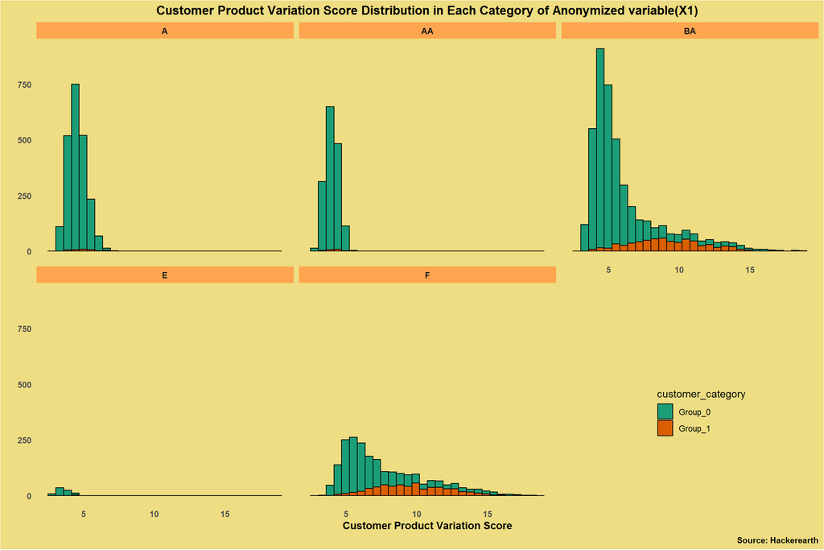

```r
train %>% mutate(customer_category =
                   recode(customer_category,
                          "0" = "Group_0",
                          "1" = "Group_1")) %>%
  na.omit() %>%
  ggplot(aes(x = customer_product_variation_score,
             fill = customer_category)) +
  geom_histogram(color = "black"
  ) +
  scale_fill_brewer(palette = "Dark2")+
  facet_wrap( ~ X1)+
  labs(x="Customer Product Variation Score",y="",caption = "Source: Hackerearth",
       title = "Customer Product Variation Score Distribution in Each Category of Anonymized variable(X1)")+
  theme(
    axis.text = element_text(face = "bold"),
    axis.title.x =  element_text(face = "bold"),
    axis.ticks = element_blank(),
    legend.position = c(0.85,.20),
    panel.grid = element_blank(),
    strip.text = element_text(face = "bold"),
    strip.background.x = element_rect(fill = "tan1"),
    plot.caption = element_text(face = "bold"),
    plot.title = element_text(face = "bold",hjust = 0.5),
    plot.background = element_rect(fill = "lightgoldenrod"),
    panel.background = element_rect(fill = "transparent"),
    axis.line = element_blank(),
    legend.background = element_rect(fill = "transparent", colour = NA),
    legend.key = element_rect(fill = NA, color = NA)
  )
```

#### Segment E has less range of customer product variation Score distribution.

#### Let's check the customer product variation Score by various categories of Anonymized variable(X1) and customer category.

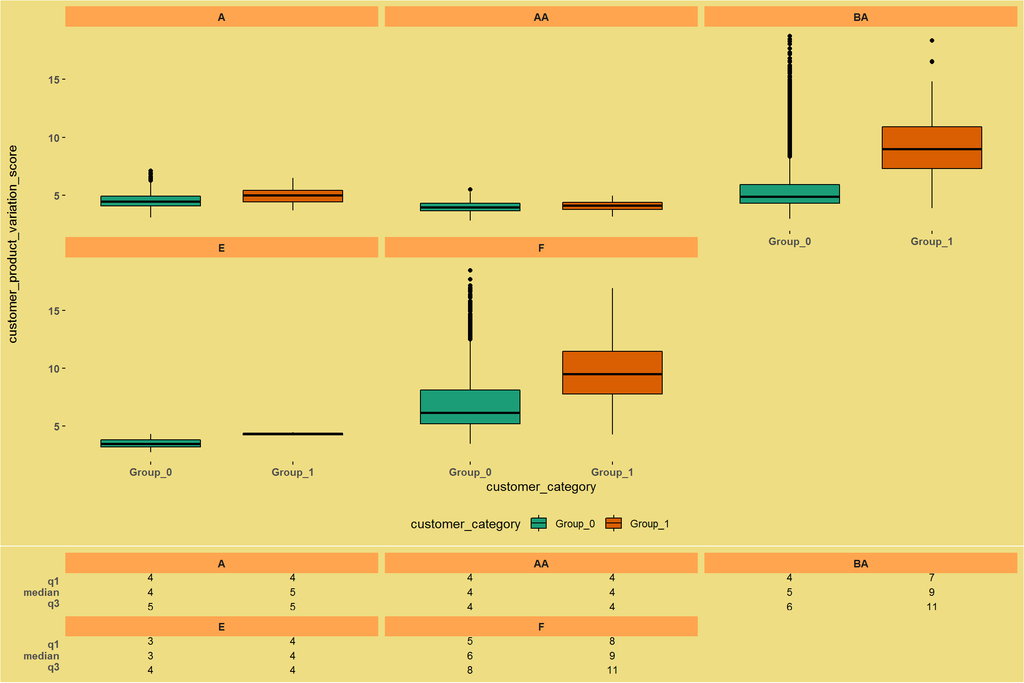

```r
ggsummarystats(
  train %>%
    mutate(customer_category =
             recode(customer_category,
                    "0" = "Group_0",
                    "1" = "Group_1")) %>%
    group_by(X1,
             customer_category) %>%
    select(X1,customer_category,
           customer_product_variation_score) %>%
    drop_na(),
  x = "customer_category",
  y = "customer_product_variation_score",
  ggfunc = ggboxplot,
  fill = "customer_category", palette = "Dark2",
  summaries = c("q1", "median","q3"),
  labeller = "label_value",

  facet.by = "X1",
  ggtheme = theme(axis.text = element_text(face = "bold"),
                  #axis.title.x =  element_text(face = "bold"),
                  axis.ticks = element_blank(),
                  legend.position = c(0.85,.20),
                  panel.grid = element_blank(),
                  strip.text = element_text(face = "bold"),
                  strip.background.x = element_rect(fill = "tan1"),
                  plot.background = element_rect(fill = "lightgoldenrod"),
                  panel.background = element_rect(fill = "transparent"),
                  axis.line = element_blank(),
                  legend.background = element_rect(fill = "transparent", colour = NA),
                  legend.key = element_rect(fill = NA, color = NA)
  ) ,legend = "bottom"
)
```

#### The above chart shows that the group 0 customer category has more number of outliers in the BA and F categories of Anonymized variable(X1).

### Customer Order Score

#### Let's check the customer order score

#### customer order score, the score based on the number of successful order delivery which has ordered by the customer.

#### Let's look quick summary of customer order score

```r
summary(train$customer_order_score)
```

```
##    Min. 1st Qu.  Median    Mean 3rd Qu.    Max.    NA's
##  0.3633  2.4540  3.1184  3.1501  3.7566  9.0902      66
```

#### The summary shows no negative order score are there and the mean is 3.1501

#### binwidth selected by using Freedman–Diaconis rule.

```r
customer_order_scorebin<-hist(train$customer_order_score,breaks = "FD",plot = F)
```

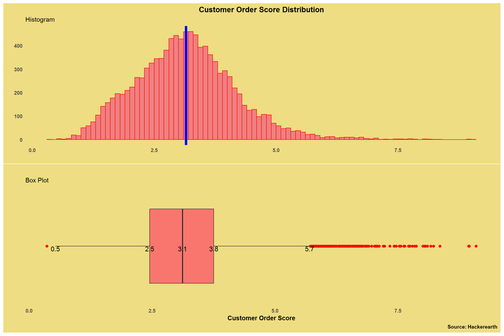

```r
customer_order_score_his <- train %>%
  na.omit() %>%
  ggplot() +
  aes(x = customer_order_score) +
  geom_histogram(breaks = customer_order_scorebin$breaks,
                 color="red",
                 fill="lightcoral"

  ) +
  geom_vline(aes(xintercept = mean(customer_order_score)),
             col='blue',size=2)+

  theme_minimal() +
  labs(x = "",
       y = "",
       subtitle = "Histogram",
       title = "Customer Order Score Distribution"
  ) +
  theme_dark() +
  theme(
    axis.ticks = element_blank(),
    axis.title = element_text(face = "bold"),
    axis.text = element_text(face = "bold"),
    plot.title = element_text(hjust = 0.5, face = "bold"),
    plot.caption = element_text(face = "bold"),
    legend.background = element_rect(fill = "transparent", colour = NA),
    panel.grid = element_blank(),
    plot.background = element_rect(fill = "lightgoldenrod"),
    panel.background = element_rect(fill = "transparent")
  )






customer_order_score_box <- train %>%
  ggplot(aes(y="",x= customer_order_score,fill="lightcoral")) +
  geom_boxplot(varwidth=T,
               outlier.color  = "red",
               outlier.size = 2) +

  stat_summary( geom="text", fun = box_summary ,
                size=4,vjust=1,
                #fun.args=list(probs=c(0,.5,.25,.75)),
                aes(
                  label=sprintf("%0.1f", ..x..))) +
  labs(x = "Customer Order Score",
       y = "",
       subtitle = "Box Plot",
       caption = "Source: Hackerearth",
       title = "") +
  theme_dark() +
  theme(
    axis.ticks = element_blank(),
    axis.title = element_text(face = "bold"),
    axis.text = element_text(face = "bold"),
    plot.title = element_text(hjust = 0.5, face = "bold"),
    plot.caption = element_text(face = "bold"),
    legend.position = "none",
    panel.grid = element_blank(),
    plot.background = element_rect(fill = "lightgoldenrod"),
    panel.background = element_rect(fill = "transparent")
  )


customer_order_score_his/customer_order_score_box
```

#### The above histogram chart says that the customer order score is normally distributed and there is no skewness

#### The boxplot explains there are outliers in the above upper limits.

#### Let's analyze the customer order score with more than one variable.

#### The following chart to analyze the customer order score by various customer_active_segment and customer category.

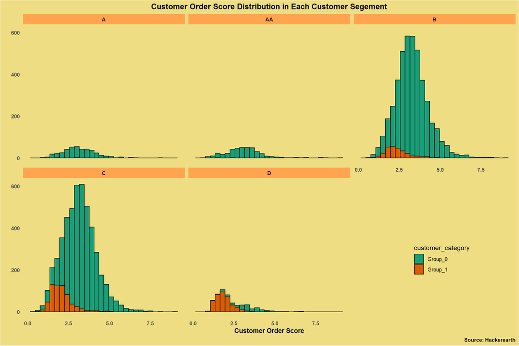

```r
train %>% mutate(customer_category =
                   recode(customer_category,
                          "0" = "Group_0",
                          "1" = "Group_1")) %>%
  na.omit() %>%
  ggplot(aes(x = customer_order_score,
             fill = customer_category)) +
  geom_histogram(color = "black"
  ) +
  scale_fill_brewer(palette = "Dark2")+
  facet_wrap( ~ customer_active_segment)+
  labs(x="Customer Order Score",y="",caption = "Source: Hackerearth",
       title = "Customer Order Score Distribution in Each Customer Segement")+
  theme(
    axis.text = element_text(face = "bold"),
    axis.title.x =  element_text(face = "bold"),
    axis.ticks = element_blank(),
    legend.position = c(0.85,.20),
    panel.grid = element_blank(),
    strip.text = element_text(face = "bold"),
    strip.background.x = element_rect(fill = "tan1"),
    plot.caption = element_text(face = "bold"),
    plot.title = element_text(face = "bold",hjust = 0.5),
    plot.background = element_rect(fill = "lightgoldenrod"),
    panel.background = element_rect(fill = "transparent"),
    axis.line = element_blank(),
    legend.background = element_rect(fill = "transparent", colour = NA),
    legend.key = element_rect(fill = NA, color = NA)
  )
```

#### The above chart shows that the customer order score range has different in each customer active segment. Customer category classification also shows a lot of differences.

#### In the next plot let's see any outlier points in customer order score by various customer_active_segment and Customer category.

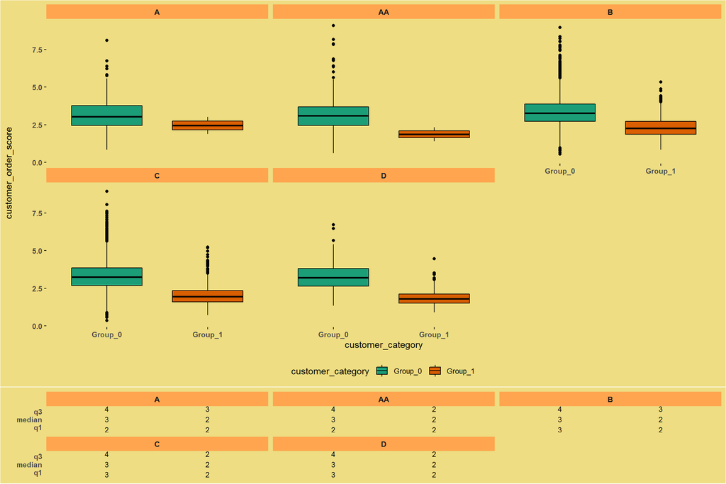

```r
ggsummarystats(
  train %>%
    mutate(customer_category =
             recode(customer_category,
                    "0" = "Group_0",
                    "1" = "Group_1")) %>%
    group_by(customer_active_segment,
             customer_category) %>%
    select(customer_active_segment,customer_category,
           customer_order_score) %>%
    drop_na(),
  x = "customer_category",
  y = "customer_order_score",
  ggfunc = ggboxplot,
  fill = "customer_category", palette = "Dark2",
  summaries = c("q3", "median","q1"),
  labeller = "label_value",
  facet.by = "customer_active_segment",
  ggtheme = theme(axis.text = element_text(face = "bold"),
                  #axis.title.x =  element_text(face = "bold"),
                  axis.ticks = element_blank(),
                  legend.position = c(0.85,.20),
                  panel.grid = element_blank(),
                  strip.text = element_text(face = "bold"),
                  strip.background.x = element_rect(fill = "tan1"),
                  plot.background = element_rect(fill = "lightgoldenrod"),
                  panel.background = element_rect(fill = "transparent"),
                  axis.line = element_blank(),
                  legend.background = element_rect(fill = "transparent", colour = NA),
                  legend.key = element_rect(fill = NA, color = NA)),
  legend = "bottom"
)
```

#### The above chart shows that the group 0 customer category has more number of outliers in all active Segments.

#### group 1 have outliers in B, C, and D customer active segment.

#### The following chart to analyze the customer order score by various category of Anonymized variable(X1) and customer category.

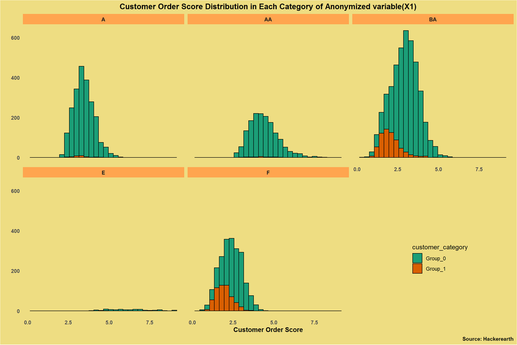

```r
train %>% mutate(customer_category =
                   recode(customer_category,
                          "0" = "Group_0",
                          "1" = "Group_1")) %>%
  na.omit() %>%
  ggplot(aes(x = customer_order_score,
             fill = customer_category)) +
  geom_histogram(color = "black"
  ) +
  scale_fill_brewer(palette = "Dark2")+
  facet_wrap( ~ X1)+
  labs(x="Customer Order Score",y="",caption = "Source: Hackerearth",
       title = "Customer Order Score Distribution in Each Category of Anonymized variable(X1)")+
  theme(
    axis.text = element_text(face = "bold"),
    axis.title.x =  element_text(face = "bold"),
    axis.ticks = element_blank(),
    legend.position = c(0.85,.20),
    panel.grid = element_blank(),
    strip.text = element_text(face = "bold"),
    strip.background.x = element_rect(fill = "tan1"),
    plot.caption = element_text(face = "bold"),
    plot.title = element_text(face = "bold",hjust = 0.5),
    plot.background = element_rect(fill = "lightgoldenrod"),
    panel.background = element_rect(fill = "transparent"),
    axis.line = element_blank(),
    legend.background = element_rect(fill = "transparent", colour = NA),
    legend.key = element_rect(fill = NA, color = NA)
  )
```

#### Let's check the customer order score by various categories of Anonymized variable(X1) and customer category.

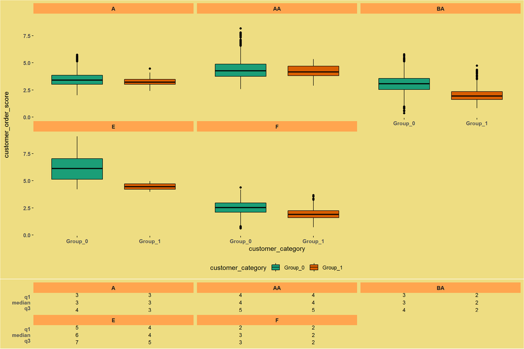

```r
ggsummarystats(
  train %>%
    mutate(customer_category =
             recode(customer_category,
                    "0" = "Group_0",
                    "1" = "Group_1")) %>%
    group_by(X1,
             customer_category) %>%
    select(X1,customer_category,
           customer_order_score) %>%
    drop_na(),
  x = "customer_category",
  y = "customer_order_score",
  ggfunc = ggboxplot,
  fill = "customer_category", palette = "Dark2",
  summaries = c("q1", "median","q3"),
  labeller = "label_value",

  facet.by = "X1",
  ggtheme = theme(axis.text = element_text(face = "bold"),
                  #axis.title.x =  element_text(face = "bold"),
                  axis.ticks = element_blank(),
                  legend.position = c(0.85,.20),
                  panel.grid = element_blank(),
                  strip.text = element_text(face = "bold"),
                  strip.background.x = element_rect(fill = "tan1"),
                  plot.background = element_rect(fill = "lightgoldenrod"),
                  panel.background = element_rect(fill = "transparent"),
                  axis.line = element_blank(),
                  legend.background = element_rect(fill = "transparent", colour = NA),
                  legend.key = element_rect(fill = NA, color = NA)
  ) ,legend = "bottom"
)
```

#### The above chart shows that the group 0 customer category has more number of outliers in the A, AA, BA categories of Anonymized variable(X1).

#### group 1 has more outliers in BAF categories of Anonymized variable(X1).

### Customer Affinity Score

#### Let's check the customer affinity score

#### customer affinity score, the score based on the affinity of the customer towards the website.

#### Let's look quick summary of customer affinity score

```r
summary(train$customer_affinity_score)
```

```
##     Min.  1st Qu.   Median     Mean  3rd Qu.     Max.
##  -0.4868   4.5301  12.6534  17.0618  23.1146 248.5528
```

##### The summary shows negative affinity score is there and the mean is 17.0618.

#### binwidth selected by using Freedman–Diaconis rule.

```r
customer_affinity_scorebin<-hist(train$customer_affinity_score,breaks = "FD",plot = F)
```

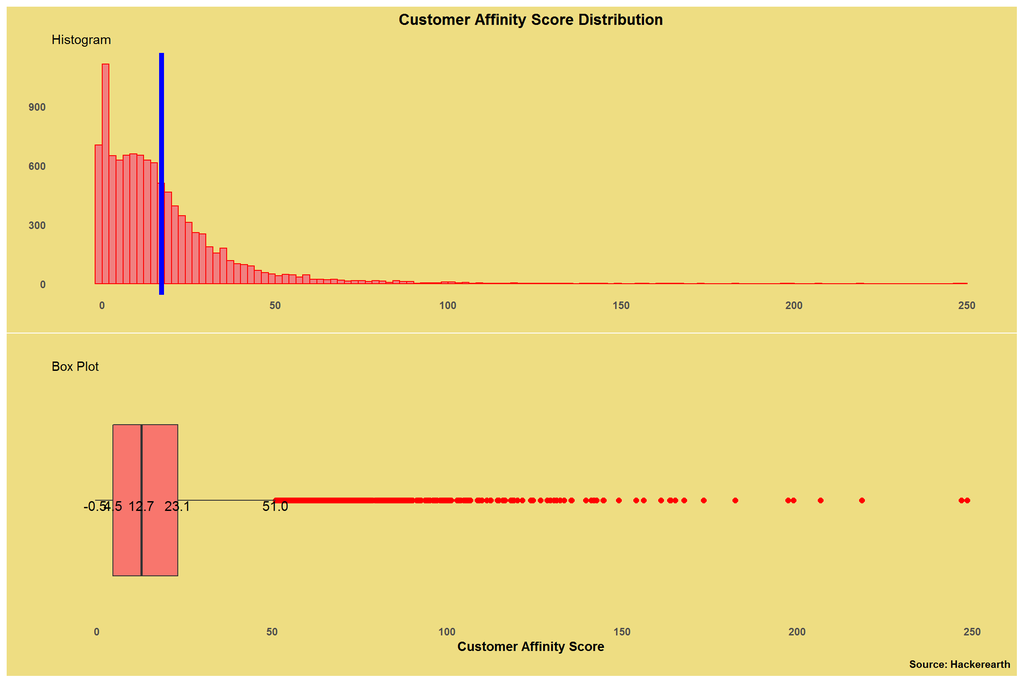

```r
customer_affinity_score_his <- train %>%
  na.omit() %>%
  ggplot() +
  aes(x = customer_affinity_score) +
  geom_histogram(breaks = customer_affinity_scorebin$breaks,
                 color="red",
                 fill="lightcoral"

  ) +
  geom_vline(aes(xintercept = mean(customer_affinity_score)),
             col='blue',size=2)+

  theme_minimal() +
  labs(x = "",
       y = "",
       subtitle = "Histogram",
       title = "Customer Affinity Score Distribution"
  ) +
  theme_dark() +
  theme(
    axis.ticks = element_blank(),
    axis.title = element_text(face = "bold"),
    axis.text = element_text(face = "bold"),
    plot.title = element_text(hjust = 0.5, face = "bold"),
    plot.caption = element_text(face = "bold"),
    legend.background = element_rect(fill = "transparent", colour = NA),
    panel.grid = element_blank(),
    plot.background = element_rect(fill = "lightgoldenrod"),
    panel.background = element_rect(fill = "transparent")
  )



customer_affinity_score_box <- train %>%
  ggplot(aes(y="",x= customer_affinity_score,fill="lightcoral")) +
  geom_boxplot(varwidth=T,
               outlier.color  = "red",
               outlier.size = 2) +

  stat_summary( geom="text", fun = box_summary ,
                size=4,vjust=1,
                #fun.args=list(probs=c(0,.5,.25,.75)),
                aes(
                  label=sprintf("%0.1f", ..x..))) +
  labs(x = "Customer Affinity Score",
       y = "",
       subtitle = "Box Plot",
       caption = "Source: Hackerearth",
       title = "") +
  theme_dark() +
  theme(
    axis.ticks = element_blank(),
    axis.title = element_text(face = "bold"),
    axis.text = element_text(face = "bold"),
    plot.title = element_text(hjust = 0.5, face = "bold"),
    plot.caption = element_text(face = "bold"),
    legend.position = "none",
    panel.grid = element_blank(),
    plot.background = element_rect(fill = "lightgoldenrod"),
    panel.background = element_rect(fill = "transparent")
  )


customer_affinity_score_his/customer_affinity_score_box
```

#### The above histogram chart says that the customer affinity score is right-skewed(most of customer affinity score falls below the mean)

#### The boxplot explains there are outliers in the above upper limits .

#### Let's analyze the customer affinity score with more than one variable.

#### The following chart to analyze the customer affinity score by various customer_active_segment and customer category.

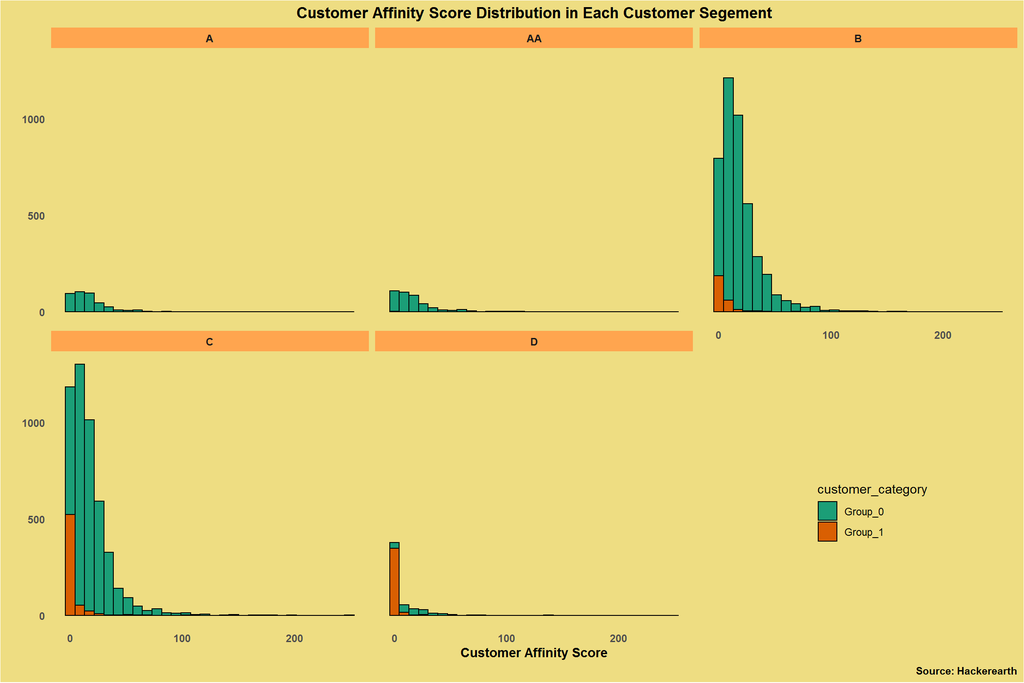

```r
train %>% mutate(customer_category =
                   recode(customer_category,
                          "0" = "Group_0",
                          "1" = "Group_1")) %>%
  na.omit() %>%
  ggplot(aes(x = customer_affinity_score,
             fill = customer_category)) +
  geom_histogram(color = "black"
  ) +
  scale_fill_brewer(palette = "Dark2")+
  facet_wrap( ~ customer_active_segment)+
  labs(x="Customer Affinity Score",y="",caption = "Source: Hackerearth",
       title = "Customer Affinity Score Distribution in Each Customer Segement")+
  theme(
    axis.text = element_text(face = "bold"),
    axis.title.x =  element_text(face = "bold"),
    axis.ticks = element_blank(),
    legend.position = c(0.85,.20),
    panel.grid = element_blank(),
    strip.text = element_text(face = "bold"),
    strip.background.x = element_rect(fill = "tan1"),
    plot.caption = element_text(face = "bold"),
    plot.title = element_text(face = "bold",hjust = 0.5),
    plot.background = element_rect(fill = "lightgoldenrod"),
    panel.background = element_rect(fill = "transparent"),
    axis.line = element_blank(),
    legend.background = element_rect(fill = "transparent", colour = NA),
    legend.key = element_rect(fill = NA, color = NA)
  )
```

#### The above chart shows that the customer affinity score range has different in each customer active segment. Customer category classification also shows a lot of differences.

#### In the next plot let's see any outlier points in customer affinity score by various customer_active_segment and Customer category.

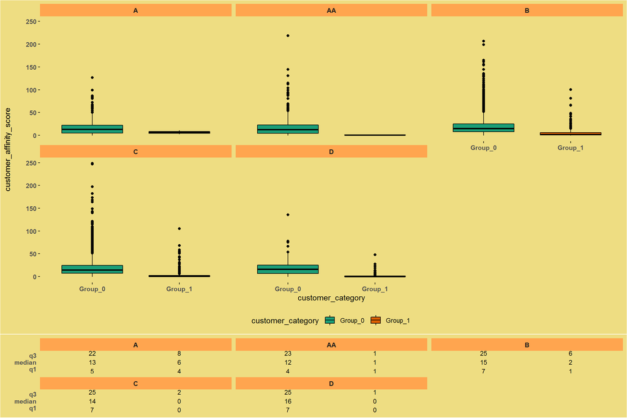

```r
ggsummarystats(
  train %>%
    mutate(customer_category =
             recode(customer_category,
                    "0" = "Group_0",
                    "1" = "Group_1")) %>%
    group_by(customer_active_segment,
             customer_category) %>%
    select(customer_active_segment,customer_category,
           customer_affinity_score) %>%
    drop_na(),
  x = "customer_category",
  y = "customer_affinity_score",
  ggfunc = ggboxplot,
  fill = "customer_category", palette = "Dark2",
  summaries = c("q3", "median","q1"),
  labeller = "label_value",
  facet.by = "customer_active_segment",
  ggtheme = theme(axis.text = element_text(face = "bold"),
                  #axis.title.x =  element_text(face = "bold"),
                  axis.ticks = element_blank(),
                  legend.position = c(0.85,.20),
                  panel.grid = element_blank(),
                  strip.text = element_text(face = "bold"),
                  strip.background.x = element_rect(fill = "tan1"),
                  plot.background = element_rect(fill = "lightgoldenrod"),
                  panel.background = element_rect(fill = "transparent"),
                  axis.line = element_blank(),
                  legend.background = element_rect(fill = "transparent", colour = NA),
                  legend.key = element_rect(fill = NA, color = NA)),
  legend = "bottom"
)
```

#### The above chart shows that the group 0 customer category has more number of outliers in all active Segments.

#### group 1 have outliers in B, C, and D customer active segment.

#### The following chart to analyze the customer affinity score by various category of Anonymized variable(X1) and customer category.

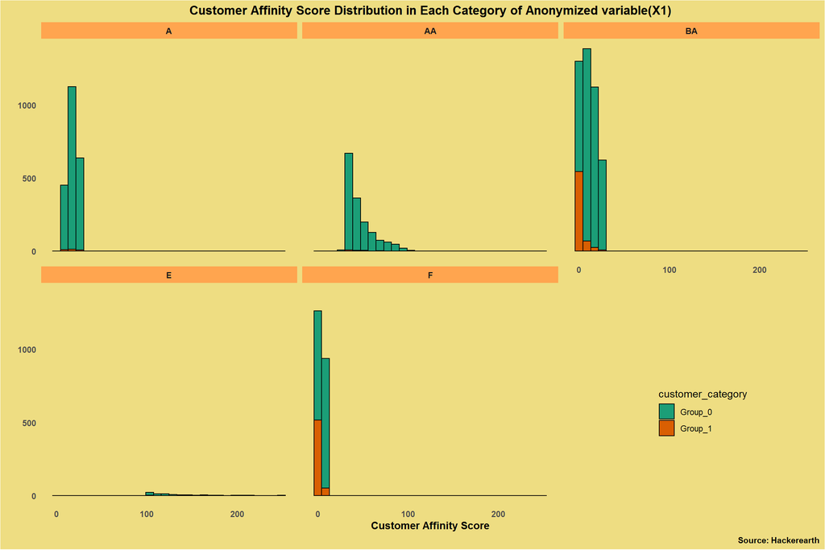

```r
train %>% mutate(customer_category =
                   recode(customer_category,
                          "0" = "Group_0",
                          "1" = "Group_1")) %>%
  na.omit() %>%
  ggplot(aes(x = customer_affinity_score,
             fill = customer_category)) +
  geom_histogram(color = "black"
  ) +
  scale_fill_brewer(palette = "Dark2")+
  facet_wrap( ~ X1)+
  labs(x="Customer Affinity Score",y="",caption = "Source: Hackerearth",
       title = "Customer Affinity Score Distribution in Each Category of Anonymized variable(X1)")+
  theme(
    axis.text = element_text(face = "bold"),
    axis.title.x =  element_text(face = "bold"),
    axis.ticks = element_blank(),
    legend.position = c(0.85,.20),
    panel.grid = element_blank(),
    strip.text = element_text(face = "bold"),
    strip.background.x = element_rect(fill = "tan1"),
    plot.background = element_rect(fill = "lightgoldenrod"),
    plot.caption = element_text(face = "bold"),
    plot.title = element_text(face = "bold",hjust = 0.5),
    panel.background = element_rect(fill = "transparent"),
    axis.line = element_blank(),
    legend.background = element_rect(fill = "transparent", colour = NA),
    legend.key = element_rect(fill = NA, color = NA)
  )
```

#### Let's check the customer affinity score by various categories of Anonymized variable(X1) and customer category.

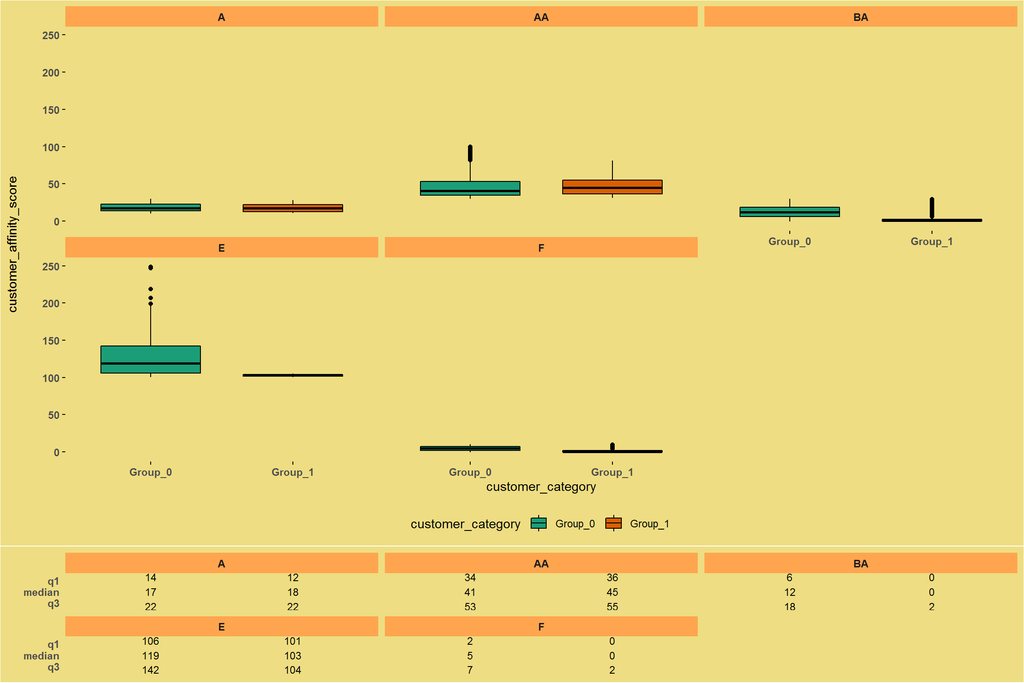

```r
ggsummarystats(
  train %>%
    mutate(customer_category =
             recode(customer_category,
                    "0" = "Group_0",
                    "1" = "Group_1")) %>%
    group_by(X1,
             customer_category) %>%
    select(X1,customer_category,
           customer_affinity_score) %>%
    drop_na(),
  x = "customer_category",
  y = "customer_affinity_score",
  ggfunc = ggboxplot,
  fill = "customer_category", palette = "Dark2",
  summaries = c("q1", "median","q3"),
  labeller = "label_value",

  facet.by = "X1",
  ggtheme = theme(axis.text = element_text(face = "bold"),
                  #axis.title.x =  element_text(face = "bold"),
                  axis.ticks = element_blank(),
                  legend.position = c(0.85,.20),
                  panel.grid = element_blank(),
                  strip.text = element_text(face = "bold"),
                  strip.background.x = element_rect(fill = "tan1"),
                  plot.background = element_rect(fill = "lightgoldenrod"),
                  panel.background = element_rect(fill = "transparent"),
                  axis.line = element_blank(),
                  legend.background = element_rect(fill = "transparent", colour = NA),
                  legend.key = element_rect(fill = NA, color = NA)
  ) ,legend = "bottom"
)
```

##### The above chart shows that the group 0 customer category has more number of outliers in AA, E categories of Anonymized variable(X1).

#### group_1 have more outliers in BA, F categories of Anonymized variable(X1).

### Customer Active Segment

#### Let's check the customer active segment with customer category.

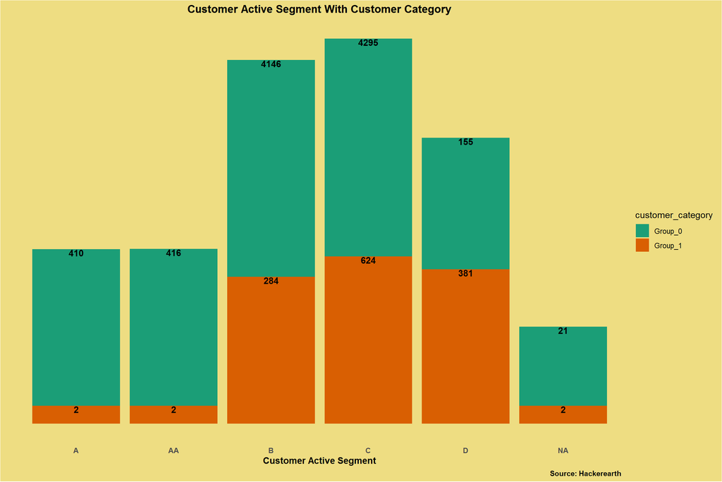

```r
train %>%
  mutate(customer_category =
           recode(customer_category,
                  "0" = "Group_0",
                  "1" = "Group_1")) %>%
  group_by(customer_active_segment,
           customer_category) %>%
  summarise(counts=n()) %>%
  select(customer_active_segment,customer_category,counts) %>%
  ggplot(aes(x=customer_active_segment,y=log(counts),
             fill=customer_category,label=counts))+
  geom_bar(stat =  "identity")+
  geom_text(position="stack",vjust=1,fontface="bold")+
  scale_fill_brewer(palette = "Dark2")+
  labs(x="Customer Active Segment",
       y="",caption = "Source: Hackerearth",
       title = "Customer Active Segment With Customer Category")+
  theme(axis.text.x =  element_text(face = "bold"),
        axis.text.y =  element_blank(),
        axis.title.x =  element_text(face = "bold"),
        axis.ticks = element_blank(),
        panel.grid = element_blank(),
        strip.text = element_text(face = "bold"),
        strip.background.x = element_rect(fill = "tan1"),
        plot.caption = element_text(face = "bold"),
        plot.title = element_text(face = "bold",hjust = 0.5),
        plot.background = element_rect(fill = "lightgoldenrod"),
        panel.background = element_rect(fill = "transparent"),
        axis.line = element_blank(),
        legend.background = element_rect(fill = "transparent", colour = NA),
        legend.key = element_rect(fill = NA, color = NA)
  )
```

#### The above chart explains that C segment has more number of group_0 and group_1 category customers and the A and AA segments have less number of group_1 category customers.

#### NA values present in customer active segment variable.

### Anonymized Variable(X1)

#### Let's analyze the Anonymized Variable(X1) With Customer Category.

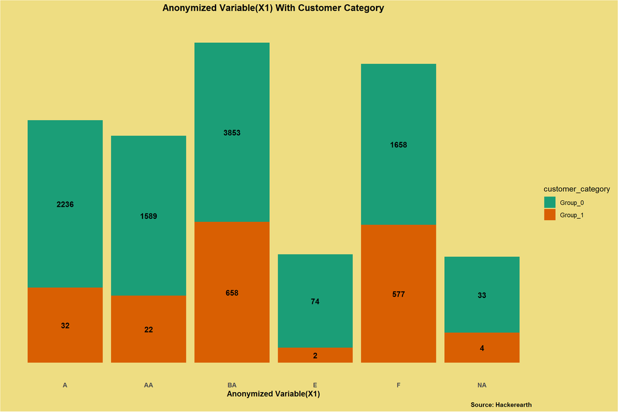

```r
train %>%
  mutate(customer_category =
           recode(customer_category,
                  "0" = "Group_0",
                  "1" = "Group_1")) %>%
  group_by(
    customer_category,X1) %>%
  summarise(counts=n()) %>%
  select(X1,customer_category,counts) %>%
  ggplot(aes(x=X1,y=log(counts),
             fill=customer_category,label=counts))+
  geom_bar(stat =  "identity")+
  geom_text(fontface="bold",position = position_stack(vjust=0.5))+
  scale_fill_brewer(palette = "Dark2")+
  labs(x="Anonymized Variable(X1)",caption = "Source: Hackerearth",
       y="",
       title = "Anonymized Variable(X1) With Customer Category\n")+
  theme(axis.text.x =  element_text(face = "bold"),
        axis.text.y =  element_blank(),
        axis.title.x =  element_text(face = "bold"),
        axis.ticks = element_blank(),
        panel.grid = element_blank(),
        strip.text = element_text(face = "bold"),
        strip.background.x = element_rect(fill = "tan1"),
        plot.caption = element_text(face = "bold"),
        plot.title = element_text(face = "bold",hjust = 0.5),
        plot.background = element_rect(fill = "lightgoldenrod"),
        panel.background = element_rect(fill = "transparent"),
        plot.subtitle = element_text(face = "bold",hjust=0.5),
        axis.line = element_blank(),
        legend.background = element_rect(fill = "transparent", colour = NA),
        legend.key = element_rect(fill = NA, color = NA)
  )
```

#### The above chart explains that the BA category of the anonymized variable(X1) has more number of customers in both customer groups.

#### E category of the anonymized variable(X1) has less number of customers in group 1.

#### NA values present in Anonymized variable(X1).

#### Let's analyze the customer active segment and Anonymized Variable(X1) and see how many customers in group_0 and group_1.

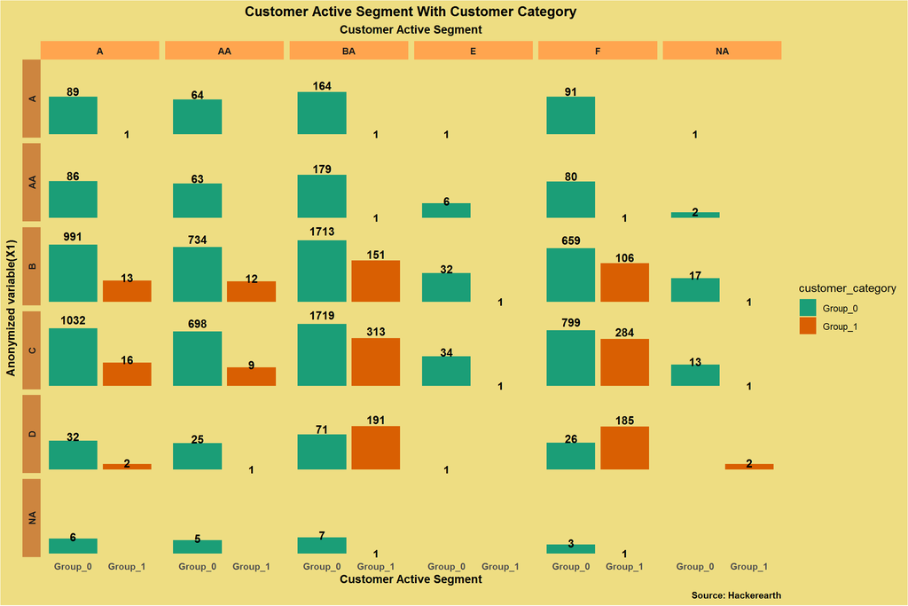

```r
train %>%
  mutate(customer_category =
           recode(customer_category,
                  "0" = "Group_0",
                  "1" = "Group_1")) %>%
  group_by(customer_active_segment,
           customer_category,X1) %>%
  summarise(counts=n()) %>%
  select(X1,customer_category,customer_active_segment,counts) %>%
  ggplot(aes(x=customer_category,y=log(counts),
             fill=customer_category,label=counts))+
  geom_bar(stat =  "identity")+
  geom_text(fontface="bold",position = position_stack(vjust = 1.15))+
  scale_fill_brewer(palette = "Dark2")+
  labs(x="Customer Active Segment",
       y="Anonymized variable(X1)",caption = "Source: Hackerearth",
       subtitle = "Customer Active Segment",
       title = "Customer Active Segment With Customer Category")+
  facet_grid(~customer_active_segment~X1,switch = "y")+
  theme(axis.text.x =  element_text(face = "bold"),
        axis.text.y =  element_blank(),
        axis.title =  element_text(face = "bold"),
        axis.ticks = element_blank(),
        panel.grid = element_blank(),
        strip.text = element_text(face = "bold"),
        strip.background.x = element_rect(fill = "tan1"),
        strip.background.y = element_rect(fill = "peru"),
        plot.background = element_rect(fill = "lightgoldenrod"),
        plot.caption = element_text(face = "bold"),
        plot.title = element_text(face = "bold",hjust = 0.5),
        plot.subtitle = element_text(face = "bold",hjust=0.5),
        panel.background = element_rect(fill = "transparent"),
        axis.line = element_blank(),
        legend.background = element_rect(fill = "transparent", colour = NA),
        legend.key = element_rect(fill = NA, color = NA)
  )
```

#### The above chart explains that in the Anonymized variable(X1)'s category A and AA, all categories of customer active segment have less number(less than 2) of group 1 category customers.

#### NA values present in both Anonymized variable(X1) and customer active segment variable.

#### The following combo has doesn't have group 1 category customers.

#### Anonymized variable(X1) A and customer active segment AA, E, F.

#### Anonymized variable(X1) Aa and customer active segment A, AA, E.

#### Anonymized variable(X1) D and customer active segment E.

### Correlation Analysis

#### Let's check the correlation between the numerical Variables.

#### For correlation chart can use the ggcorrplot library.

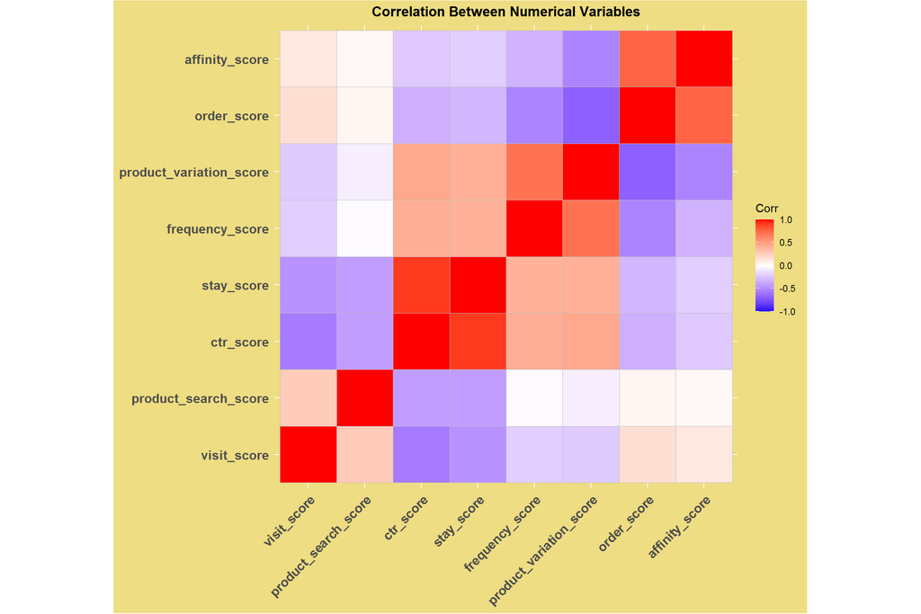

```r
cor_score <- cor(train[,c(2:9)] %>%
                   rename_all(~str_remove_all(.,"customer_")) %>%
                drop_na())

ggcorrplot(cor_score,method = "square",
         title="Correlation Between Numerical Variables",
         ggtheme=theme(
           axis.ticks = element_blank(),
           axis.text =  element_text(face = "bold"),
           panel.background = element_rect(fill = "transparent"),
           axis.line = element_blank(),
           legend.background = element_rect(fill = "transparent", colour = NA),
           legend.key = element_rect(fill = NA, color = NA),
           plot.background = element_rect(fill = "lightgoldenrod"),
           plot.title = element_text(face="bold",hjust=0.5)))
```

### Missing Value Analysis

#### Let's visualize the missing value count in each variable.

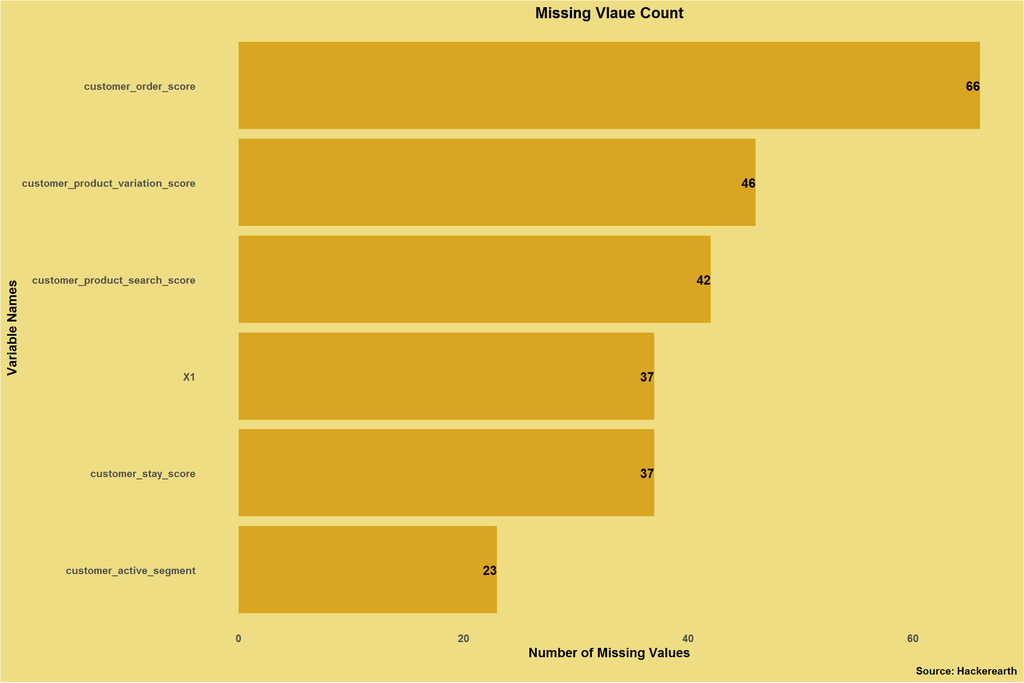

```r
train[,c(2:11)] %>%
  gather(key = "key", value = "val") %>%
  group_by(key) %>%
  summarise(counts = sum(is.na(val))) %>%
  filter(counts>0) %>%
  ggplot(aes(x= reorder(key,counts),y=counts,label=counts))+
  geom_bar(stat="identity",fill="goldenrod")+
  geom_text(hjust=1,fontface="bold")+
  labs(
    x="Variable Names",
    y="Number of Missing Values",
    title="Missing Vlaue Count",
    caption  = "Source: Hackerearth"
  )+
  theme(
    axis.text =  element_text(face = "bold"),
    axis.title =  element_text(face = "bold"),
    axis.ticks = element_blank(),
    panel.grid = element_blank(),
    plot.background = element_rect(fill = "lightgoldenrod"),
    plot.title = element_text(face = "bold",hjust=0.5),
    plot.caption  = element_text(face = "bold"),
    panel.background = element_rect(fill = "transparent"),
    axis.line = element_blank()
  )+
  coord_flip()
```

#### The above chart explains that the customer_order score has the highest missing values than other variables.